# REGRESION LINEAL VINOS

Tenemos 1000 vinos a los cuales les medimos 11 variables de interés: fixed acidity, volatile acidity, citric acid, residual sugar, chlorides, free sulfur dioxide, total sulfur dioxide, density, pH, sulphates y alcohol. A su vez, cada uno de estos vinos fue calificado con una nota del 0 al 10 por unos especialistas (que al calificarlos tuvieron en cuenta ´unicamente su “experiencia sensorial”). Estos datos fueron guardados en la variable quality. El objetivo de este TP es poder explicar mediante una regresión lineal la variable respuesta quality en función de las 11 variables explicativas ya mencionadas.

```r
# cargo los datos
library(caret)
library(glmnet)
library(glmnetUtils)
vinos <- read.csv("vinos_1.csv",header=TRUE,sep=",")
```

# PREPROCESAR

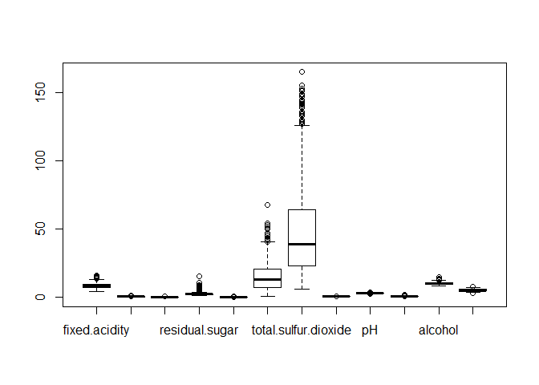

```r
boxplot(vinos)
```

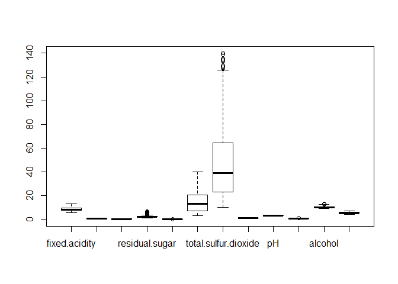

```r
reemplazar_outliers=function(x){
  # reemplaza los outliers por el valor del quantile .02 y .98 segun corresponda.
  qnt <- quantile(x,probs=c(.25,.75))
  alfa <- quantile(x,probs=c(.02,0.98))
  H<-1.5*IQR(x)
  #x[x< (qnt[1]-H)]<-alfa[1]
  #x[x>(qnt[2]+H)]<-alfa[2]
  x[x<alfa[1]]<-alfa[1]
  x[x>alfa[2]]<-alfa[2]
  return(x)
}
preprocesar=function(data){

  for (i in 1:(length(data))){
    data[,i]=reemplazar_outliers(data[,i])
    #data[,i]=as.numeric(scale(data[,i],center= TRUE, scale= TRUE))
  }
  return(data)
}

# reemplazo los outliers en todas las columnas
data <- preprocesar(vinos)
boxplot(data)
```

# MODELOS

```r
set.seed(42)
```

### SEPARO EN TRAIN Y TEST

```r
Y <- vinos[,"quality"]
train_indices<-createDataPartition(Y,p=0.8,list=FALSE) # mantiene la proporción de las clases de Y
vinos_train<- data[train_indices,]
vinos_test <- data[-train_indices,]
vinos_test_original<-vinos[-train_indices,]
```

## MODELO 4

En este modelo, considero que el logaritmo(quality) depende linealmente de las variables.

```r
# defino train control para k fold cross validation

train_control<-trainControl(method = "cv",number = 10)

# entreno el modelo lineal

vinos.fit <-train(log(quality) ~.,
                   data = vinos_train, trControl=train_control,method ="lm")

# medidas promedio de los 10 folds.

vinos.fit$results
```

```
##   intercept      RMSE  Rsquared        MAE      RMSESD RsquaredSD
## 1      TRUE 0.1101781 0.3287208 0.08656691 0.008269252 0.05882813
##         MAESD
## 1 0.005154263
```

```r
# resumen del modelo final
modeloFinal4 <- vinos.fit$finalModel
summary(modeloFinal4)
```

```
##
## Call:
## lm(formula = .outcome ~ ., data = dat)
##
## Residuals:
##      Min       1Q   Median       3Q      Max
## -0.42354 -0.06405 -0.01055  0.08195  0.29668
##
## Coefficients:
##                        Estimate Std. Error t value Pr(>|t|)
## (Intercept)           0.6763220  5.3006338   0.128 0.898504
## fixed.acidity         0.0055761  0.0063135   0.883 0.377403
## volatile.acidity     -0.1642856  0.0297165  -5.528 4.39e-08 ***
## citric.acid          -0.0766805  0.0347220  -2.208 0.027502 *
## residual.sugar        0.0022164  0.0048619   0.456 0.648610
## chlorides            -0.2474292  0.1338227  -1.849 0.064841 .
## free.sulfur.dioxide   0.0004292  0.0006176   0.695 0.487317
## total.sulfur.dioxide -0.0006679  0.0001876  -3.559 0.000394 ***
## density               0.6474854  5.4036698   0.120 0.904654
## pH                   -0.0433704  0.0455949  -0.951 0.341789
## sulphates             0.1396478  0.0287246   4.862 1.41e-06 ***
## alcohol               0.0531101  0.0062838   8.452  < 2e-16 ***
## ---
## Signif. codes:  0 '***' 0.001 '**' 0.01 '*' 0.05 '.' 0.1 ' ' 1
##
## Residual standard error: 0.1095 on 789 degrees of freedom
## Multiple R-squared:  0.3402, Adjusted R-squared:  0.331
## F-statistic: 36.98 on 11 and 789 DF,  p-value: < 2.2e-16
```

```r
# MSE de train_vinos
MSE <- mean((vinos_train[,"quality"]-exp(modeloFinal4$fitted.values))^2)
MSE
```

```
## [1] 0.3638155
```

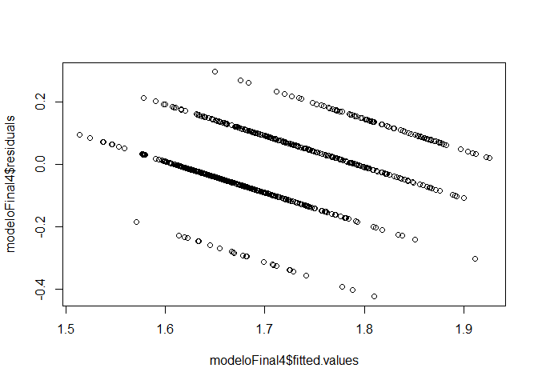

```r
plot(modeloFinal4$fitted.values,modeloFinal4$residuals)
```

```r
# MSE de test_vinos
MSE <- mean((vinos_test[,"quality"]-exp(predict(modeloFinal4,vinos_test)))^2)
MSE
```

```
## [1] 0.3889965
```

```r
MSE <- mean((vinos_test_original[,"quality"]-exp(predict(modeloFinal4,vinos_test)))^2)
MSE
```

```
## [1] 0.4649471
```

## MODELO 5

El último modelo considera “volatile.acidity”, “citric.acid”, “chlorides”, “total.sulfur.dioxide”, “sulphates”,“alcohol”,“pH” y el producto de estas variables.

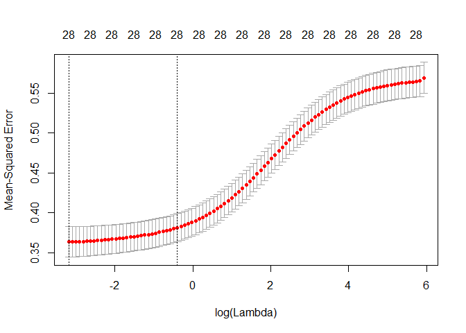

```r
vinos_train5 <- vinos_train[,match(c("volatile.acidity","citric.acid","chlorides","total.sulfur.dioxide","sulphates","alcohol","pH","quality"),colnames(vinos))]
vinos_test5 <- vinos_test[,match(c("volatile.acidity","citric.acid","chlorides","total.sulfur.dioxide","sulphates","alcohol","pH","quality"),colnames(vinos))]
l=1
for (i in 1:6){
  for (j in (i+1):7){
    vinos_train5[,8+l]<-vinos_train5[,i]*vinos_train5[,j]
    vinos_test5[,8+l]<-vinos_test5[,i]*vinos_test5[,j]
    l<-l+1
  }
}


foldid=sample(1:10,size=length(vinos_train5[,"quality"]),replace=TRUE)
cv.alpha0 <- cv.glmnet(quality~ ., data=vinos_train5,foldid=foldid,alpha=0) # Ridge
cv.alpha05 <- cv.glmnet(quality~ ., data=vinos_train5,foldid=foldid,alpha=0.5)
cv.alpha1 <- cv.glmnet(quality~ ., data=vinos_train5,foldid=foldid,alpha=1) # Lasso


plot(cv.alpha0)
```

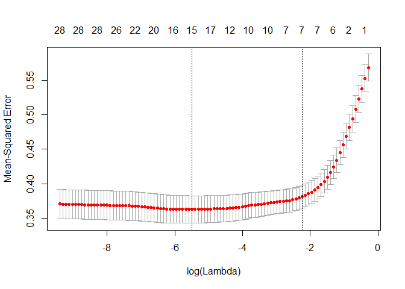

```r
plot(cv.alpha05)
```

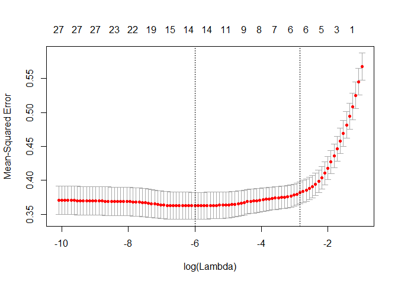

```r
plot(cv.alpha1)
```

Elijo el modelo con alpha=1 y lambda = lambda.min

```r
#MSE vinos_train
MSE<-cv.alpha1$cvm[match(cv.alpha1$lambda.min,cv.alpha1$lambda)]
MSE
```

```
## [1] 0.362377
```

```r
coef(cv.alpha1, s="lambda.min")
```

```
## 29 x 1 sparse Matrix of class "dgCMatrix"
##                                  1
## (Intercept)           4.8559915576
## volatile.acidity     -1.2468457786
## citric.acid           .
## chlorides             .
## total.sulfur.dioxide  .
## sulphates             .
## alcohol               0.1926087793
## pH                   -0.4327384361
## V9                   -0.6681885006
## V10                   2.4291441345
## V11                   0.0092494392
## V12                  -0.0604620765
## V13                   .
## V14                   .
## V15                  -1.6791738715
## V16                  -0.0001215758
## V17                   .
## V18                   0.0175299191
## V19                   .
## V20                  -0.0078867037
## V21                  -2.0652308478
## V22                   .
## V23                   .
## V24                  -0.0117138912
## V25                   .
## V26                   .
## V27                   0.1598622345
## V28                   0.0188375430
## V29                   .
```

El MSE para vinos_test es

```r
prediccion <-predict(cv.alpha1, newdata=vinos_test5, s = "lambda.min")
MSE<-mean((vinos_test5[,"quality"]-prediccion)^2)
MSE
```

```
## [1] 0.391939
```

```r
prediccion <-predict(cv.alpha1, newdata=vinos_test5, s = "lambda.min")
MSE<-mean((vinos_test_original[,"quality"]-prediccion)^2)
MSE
```

```
## [1] 0.4609823
```

# ELECCION DE MODELO

```r
vinos_prediccion <- read.csv("vinos_2.csv",header=TRUE,sep=",")
preprocesa=function(data){

  for (i in 1:(length(data))){
    data[,i]=reemplazar_outliers(data[,i])
  }
  return(data)
}
vinos_prediccion <- preprocesa(vinos_prediccion)
x=c("volatile.acidity","citric.acid","chlorides","total.sulfur.dioxide","sulphates","alcohol","pH")

vinos_p <- vinos_prediccion[,x]
vinos_p[,"quality"]<-1:599 # pongo cualquier cosa solo para que tenga "quality"
l<-1
for (i in 1:6){
  for (j in (i+1):7){
    vinos_p[,8+l]<-vinos_p[,i]*vinos_p[,j]
    vinos_p[,8+l]<-vinos_p[,i]*vinos_p[,j]
    l<-l+1
  }
}
predichos <-predict(cv.alpha1, newdata=vinos_p, s = "lambda.min")
round(predichos,3);
```

```
##            1
##   [1,] 6.254
##   [2,] 6.046
##   [3,] 6.641
##   [4,] 6.479
##   [5,] 5.593
##   [6,] 6.479
##   [7,] 6.641
##   [8,] 6.643
##   [9,] 6.414
##  [10,] 5.781
##  [11,] 6.454
##  [12,] 5.858
##  [13,] 5.117
##  [14,] 5.392
```

[output cut: 585 more lines]

```r
write.csv(round(predichos,3), file = "predichos.csv",row.names = FALSE);
```